# Math 421 - Midterm

## III. Predictive Models

Continue with the data from part I. Make sure you do not have any missing values in the data. Use the follows as the target and input variables:

*Target Variable*: Create the target variable taking value of

- `low` if the total charge of a patient (`tot`) is smaller than the median of the total charge, and
- `high` otherwise.

*Input Variables*:

- “age”,“sex”,“raceethn”,“provider”,“moa”,“mod”,“admtype”,“campus”, ‘los’

```r
medianTot <- median(df2$tot)
df2$target <- ifelse(df2$tot < medianTot, "low", "high")
inputVars <- df2 %>%
  select(age, sex, raceethn, provider, moa, mod, admtype, campus, los, target)
```

1. Use `filter` function to filter out rows where `raceethn==''` or `admtype==''`. Make sure all the categorical variables are factor, numeric variables are numeric. Set Training : Testing Split = 10 : 90

```r
library(caret)

df2 <- df2 %>%
  filter(raceethn != '', admtype != '') %>%
  mutate(sex = as.factor(sex),
         raceethn = as.factor(raceethn),
         provider = as.factor(provider),
         moa = as.factor(moa),
         mod = as.factor(mod),
         admtype = as.factor(admtype),
         campus = as.factor(campus),
         target = as.factor(target)) %>%
  mutate(across(c(age, los, tot), as.numeric))

set.seed(2020)

# random sample the rows
inputVars <- inputVars %>%
  sample_frac(0.1)

splitIndex <- createDataPartition(df2$target, p = .90,
                                  list = FALSE)
df_train <- inputVars[splitIndex,]
df_test <- inputVars[-splitIndex,]

#df_train$target <- as.factor(ifelse(df_train$target == "low", 0, 1))

df_train <- df_train[complete.cases(df_train),]
colnames(df_train)[colSums(is.na(df_train)) > 0]
```

```
## character(0)
```

```r
df_test$target <- as.factor(df_test$target)
```

2. Train a decision tree using `rpart`. Plot the decision tree. Plot the variable importance ranked by the tree.

[figure not shown]

```r
library(rpart)
library(rpart.plot)

tree_control <- rpart.control(maxdepth = 3)
tree_model <- rpart(target ~ ., data = inputVars, method = "class", control = tree_control)

library(rattle)
fancyRpartPlot(tree_model)
```

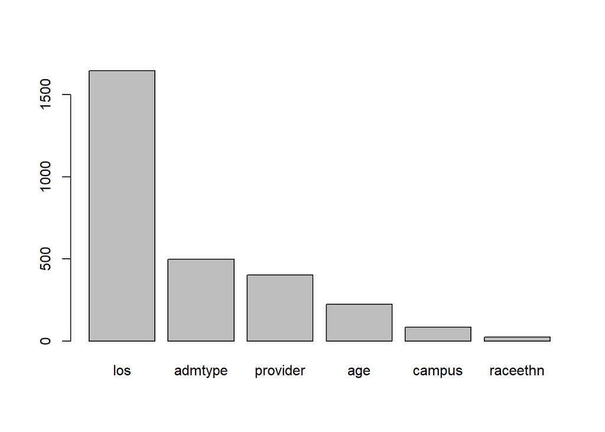

```r
barplot(tree_model$variable.importance)
```

3. Using caret for this question. Set `Training Control` to be: Use Cross-Validation of 5 folds across all models. Train & tune at least 2 different models (i.e. two different values for `method=` in the train function of caret). Plot the hyper-parameter tuning plots for each model.

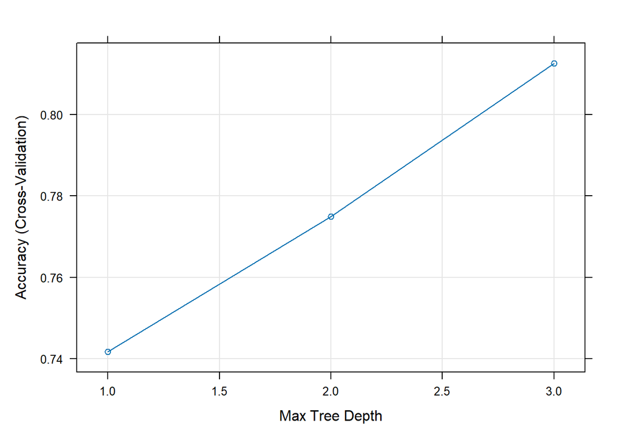

```r
trControl = trainControl(method = "cv",
                         number = 5)
tree <- train(target~., data=df_train,
                                method = "rpart2",
                                trControl = trControl)
forest_ranger <- train(target~., data=df_train,
                    method = "ranger",
                                trControl = trControl)
results <- resamples(list('Decision Tree' = tree,
                          'Random Forest' = forest_ranger))
plot(tree)
```

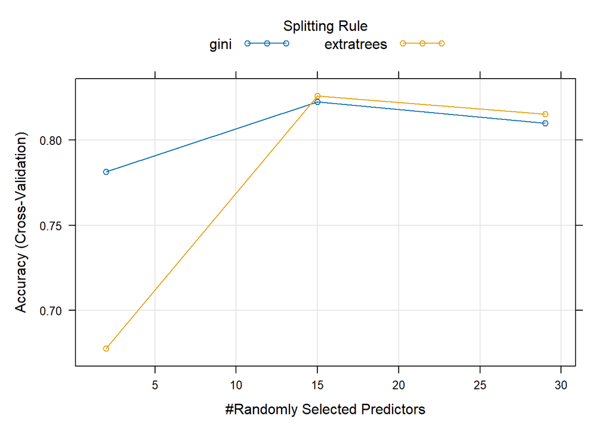

```r
plot(forest_ranger)
```

4. Plot the comparison of the models in 3.

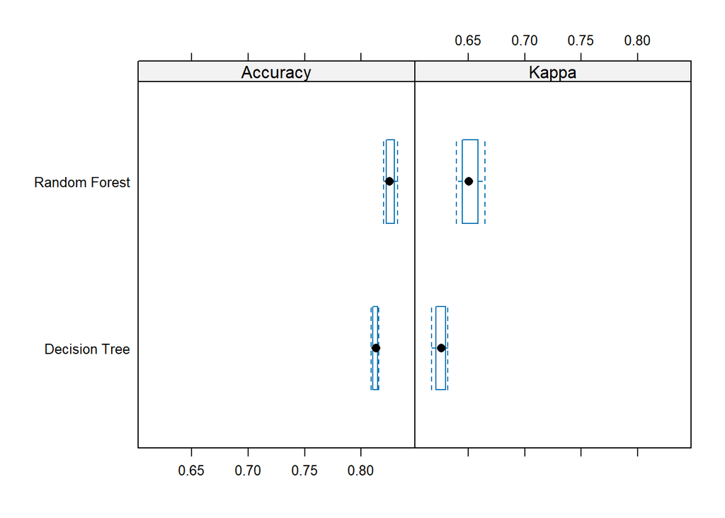

```r
bwplot(results)
```

5. What is your final selection for the model? Test the accuracy of your final model on the test data. My final selection would be the random forest because it has a higher accuracy.

```r
pred <- predict(forest_ranger, df_test)
pred <- factor(pred, levels = levels(df_test$target))
levels(df_test$target)
```

```
## [1] "high" "low"
```

```r
levels(pred)
```

```
## [1] "high" "low"
```

```r
cm <- confusionMatrix(data = pred, reference = df_test$target, positive = "high")
cm$overall[1]
```

```
##  Accuracy
## 0.8254826
```

6. Create another `target` variable (binary), decide the input variables and redo 1 to 5.

```r
meanTot <- mean(df2$tot)
df2$target <- ifelse(df2$tot < meanTot, "low", "high")
inputVars <- df2 %>%
  select(age, sex, raceethn, provider, moa, mod, admtype, campus, los, target)
```

```r
df2 <- df2 %>%
  filter(raceethn != '', admtype != '') %>%
  mutate(sex = as.factor(sex),
         raceethn = as.factor(raceethn),
         provider = as.factor(provider),
         moa = as.factor(moa),
         mod = as.factor(mod),
         admtype = as.factor(admtype),
         campus = as.factor(campus),
         target = as.factor(target)) %>%
  mutate(across(c(age, los, tot), as.numeric))

set.seed(2020)

# random sample the rows
inputVars <- inputVars %>%
  sample_frac(0.1)

splitIndex <- createDataPartition(df2$target, p = .90,
                                  list = FALSE)
df_train <- inputVars[splitIndex,]
df_test <- inputVars[-splitIndex,]

#df_train$target <- as.factor(ifelse(df_train$target == "low", 0, 1))

df_train <- df_train[complete.cases(df_train),]
colnames(df_train)[colSums(is.na(df_train)) > 0]
```

```
## character(0)
```

```r
df_test$target <- as.factor(df_test$target)
```

[figure not shown]

```r
tree_control <- rpart.control(maxdepth = 3)
tree_model <- rpart(target ~ ., data = inputVars, method = "class", control = tree_control)

fancyRpartPlot(tree_model)
```

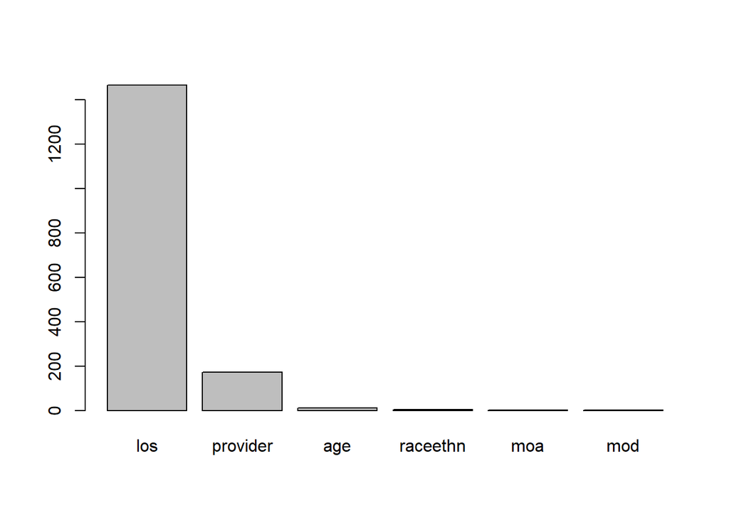

```r
barplot(tree_model$variable.importance)
```

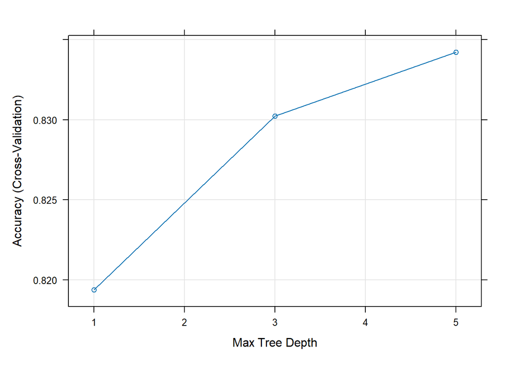

```r
trControl = trainControl(method = "cv",
                         number = 5)
tree <- train(target~., data=df_train,
                                method = "rpart2",
                                trControl = trControl)
forest_ranger <- train(target~., data=df_train,
                    method = "ranger",
                                trControl = trControl)
results <- resamples(list('Decision Tree' = tree,
                          'Random Forest' = forest_ranger))
plot(tree)
```

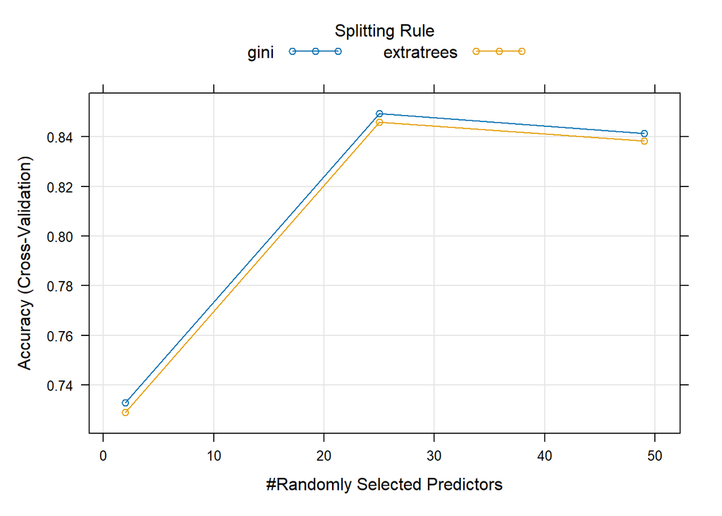

```r
plot(forest_ranger)
```

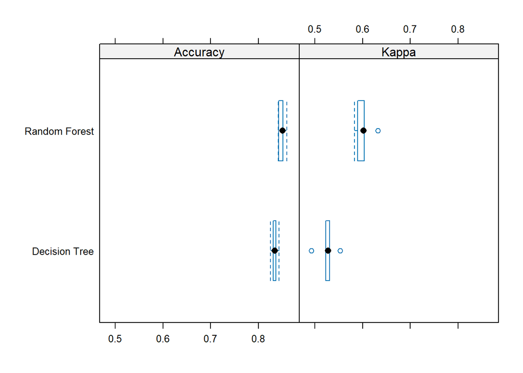

```r
bwplot(results)
```

My final selection would be the random forest because it has a higher accuracy.

```r
pred <- predict(forest_ranger, df_test)
pred <- factor(pred, levels = levels(df_test$target))
levels(df_test$target)
```

```
## [1] "high" "low"
```

```r
levels(pred)
```

```
## [1] "high" "low"
```

```r
cm <- confusionMatrix(data = pred, reference = df_test$target, positive = "high")
cm$overall[1]
```

```
##  Accuracy
## 0.8449799
```